# Homework R Code

WANG Yu

2020-12-20

# HOMWEWORK 1

## Question

Use knitr to produce 3 examples in the book.

1. The 1st example should contain texts and at least one figure.
2. The 2nd example should contains texts and at least one table.
3. The 3rd example should contain at least a couple of LaTeX formulas.

## Answer

1. Donald John Trump, president of the United States of America, is a man with great ambition. He devoted himself completely into the liberation of mankind. As a member of the Communist Party, he always remembers his duty and takes it into action. He cheated, he lay, he stole, he fooled all the Americans. He is the king of the sun. He deserves a medal weighed 5 tons.

```r
knitr::include_graphics('donald.jpg')
```

[output not shown]

- Countries have the Largest population in the world

$$\begin{array}{|c|l|l|}
\hline
rank & Country( or Region) & Population \\
\hline
1 & Mainland \ China & 1394750000 \\
& Hongkong \ China & 7482500 \\
& Taiwan \ China & 23590744 \\
& Mocao \ China & 667400 \\
\hline
2 & India & 13442700000 \\
\hline
3 & America & 328802000 \\
\hline
4 & Indonesia & 268074600 \\
\hline
5 & Bazil & 209598000 \\
\hline
6 & Pakistan & 203885000 \\
\hline
7 & Nigeria & 193392517 \\
\hline
8 & Bangladesh & 166155000 \\
\hline
9 & Russia & 146793744 \\
\hline
10 & Mexico & 126577691 \\
\hline
\end{array}$$

- Information about the fate of passengers on the fatal maiden voyage of the ocean liner ‘Titanic’.

| Class | Sex | Age | Survived | Freq |
| --- | --- | --- | --- | --- |
| 1st | Male | Child | No | 0 |
| 2nd | Male | Child | No | 0 |
| 3rd | Male | Child | No | 35 |
| Crew | Male | Child | No | 0 |
| 1st | Female | Child | No | 0 |
| 2nd | Female | Child | No | 0 |
| 3rd | Female | Child | No | 17 |
| Crew | Female | Child | No | 0 |
| 1st | Male | Adult | No | 118 |
| 2nd | Male | Adult | No | 154 |
| 3rd | Male | Adult | No | 387 |
| Crew | Male | Adult | No | 670 |
| 1st | Female | Adult | No | 4 |
| 2nd | Female | Adult | No | 13 |
| 3rd | Female | Adult | No | 89 |
| Crew | Female | Adult | No | 3 |
| 1st | Male | Child | Yes | 5 |
| 2nd | Male | Child | Yes | 11 |
| 3rd | Male | Child | Yes | 13 |
| Crew | Male | Child | Yes | 0 |
| 1st | Female | Child | Yes | 1 |
| 2nd | Female | Child | Yes | 13 |
| 3rd | Female | Child | Yes | 14 |
| Crew | Female | Child | Yes | 0 |
| 1st | Male | Adult | Yes | 57 |
| 2nd | Male | Adult | Yes | 14 |
| 3rd | Male | Adult | Yes | 75 |
| Crew | Male | Adult | Yes | 192 |
| 1st | Female | Adult | Yes | 140 |
| 2nd | Female | Adult | Yes | 80 |
| 3rd | Female | Adult | Yes | 76 |
| Crew | Female | Adult | Yes | 20 |

3. If $\{f_n\}$ is a sequence of extended real valued, measurable functions on a measurable space $X$, then each of the four functions $h,g,f^*$, and $f_*$, defined by

$$h(x) = \sup \{f_n(x):n = 1, 2, \dots\},$$

$$g(x) = \inf \{f_n(x):n = 1, 2, \dots\},$$

$$f^*(x) = \limsup_n f_n(x),$$

$$f_*(x) = \liminf_n f_n(x)$$

is measurable.

# HOMEWORK 2

## Question

3.3 The $Pareto(a, b)$ distribution has cdf

$$F(x) = 1 − (\frac{b}{x})^a , x \geq b > 0, a > 0.$$

Derive the probability inverse transformation $F^{-1}(U)$ and use the inverse transform method to simulate a random sample from the $Pareto(2, 2)$ distribution. Graph the density histogram of the sample with the $Pareto(2, 2)$ density superimposed for comparison.

3.9 The rescaled Epanechnikov kernel [85] is a symmetric density function

$$f_e(x) = \frac34(1-x^2),|x|\leq 1$$
Devroye and Gyorfi [71, p.236] give the following algorithm for simulation from this distribution. Generate iid $U1, U2, U3 \sim U(−1, 1)$. If |$U_3| \geq|U_2|\ and\ |U_3| \geq |U_1|$, deliver $U_2$; otherwise deliver $U_3$. Write a function to generate random variates from $f_e$, and construct the histogram density estimate of a large simulated random sample.

3.10 Prove that the algorithm given in Exercise 3.9 generates variates from the density $f_e$.

3.13 It can be shown that the mixture in Exercise 3.12 has a Pareto distribution with cdf

$$F(y) = 1 − (\fracβ{β+y})^r, y\geq 0.$$

(This is an alternative parameterization of the $Pareto$ cdf given in Exercise 3.3.) Generate 1000 random observations from the mixture with $r = 4$ and $\beta = 2$. Compare the empirical and theoretical ($Pareto$) distributions by graphing the density histogram of the sample and superimposing the Pareto density curve.

## Answer

### 3.3

Use inverse transform method to generate some random samples for $Pareto(2, 2)$, graph its density histogram compared with density curve of $Pareto(2, 2)$ distribution.

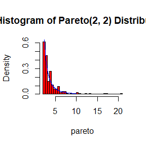

```r
# homework 3.3

rm(list = ls())
set.seed(1234)

n_sample <- 200

# generate n.sample random numbers subject to U(0, 1)
u <- runif(n_sample)

# generate Pareto distribution random numbers
pareto <- 2. * (u^(-0.5))

x <- seq(2, 10, .01)
y <- 8 / (x^3)

# draw a histogram of these numbers
hist(pareto, freq = F, col = 'red', breaks = 50, main = "Histogram of Pareto(2, 2) Distribution")
lines(x, y, col = "blue")
```

### 3.9 and 3.10

Simulate some samples with the function implemented with the idea given. Graph density histogram of these samples.

Use Kolmogorov-Smirnov tests to test whether $b$ yileds the distribution $F$. From the test, p-value is 0.8646. So these variates are from density $f_e$.

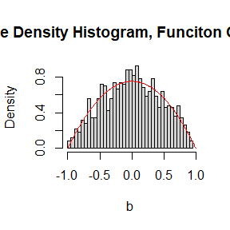

```r
rm(list=ls())
set.seed(1234)

# homework 3.9

# generate numbers yield the chosen distribution
generate <- function(n){
    result <- rep(0, n)
    u1 <- 2 * runif(n) - 1
    u2 <- 2 * runif(n) - 1
    u3 <- 2 * runif(n) - 1
    for(i in 1:n){
        if((abs(u3[i]) > abs(u2[i])) && (abs(u3[i]) > abs(u1[i]))){
            result[i] <- u2[i]
        }
        else {
            result[i] <- u3[i]
        }
    }
    result
}

b <- generate(1000)
x <- seq(-1, 1, 0.01)
y <- 0.75 * (1 - x^2)

# make a histogram of @vector b
hist(b, main = "Sample Density Histogram, Funciton Curve of fe", freq = F, breaks = 50)
# line the density function
lines(x, y, col = "red")
```

```r
# homework 3.10

# CDF of the chosen distribution
F <- function(x) {
    0.75 * x - 0.25 * (x^3) + 0.5
}

# use Kolmogorov-Smirnov tests to test whether b yileds F
ks.test(b, F)
```

```
#
#   One-sample Kolmogorov-Smirnov test
#
# data:  b
# D = 0.018967, p-value = 0.8646
# alternative hypothesis: two-sided
```

### 3.10

We can simplify the question by regarding $u_1,u_2,u_3 \sim U(0,1)$ and choosing $u_2$ if $u_3\geq u_1,u_2$ otherwise $u_3$. Then, our goal is to proof that $u\sim f_e = \frac32(1-x^2);0\leq x\leq 1$.

It is easy to prove that $p(u=u_{(1)})=p(u=u_{(2)})$ since
$$u_1\geq u_2 \geq u_3,\ u = u_{(1)}=u_3$$
$$u_1\geq u_3 \geq u_2,\ u=u_{(2)}=u_3$$
$$u_2\geq u_1 \geq u_3,\ u = u_{(1)}=u_3$$
$$u_2\geq u_3 \geq u_1,\ u= u_{(2)}=u_3$$
$$u_3\geq u_2 \geq u_1,\ u= u_{(2)}=u_2$$
$$u_3\geq u_1 \geq u_2,\ u= u_{(1)}=u_2$$
Let $A$ denote the events that $u=u_{(1)}$, hence we get:

$$\begin{aligned}
P(u\leq x)
&= P(A)P(u\leq x|A)+P(A^c)P(u\leq x|A^c)\\
&= P(A)P(u_{(1)}\leq x)+P(A^c)P(u_{(2)}\leq x)\\
&= \frac12 (\int_0^x 3(1-t)^2\mathrm{d}t + \int_0^x 6t(1-t)\mathrm{d}t)\\
&= \frac32x - \frac12 x^3,\ (0<x<1)
\end{aligned}$$
and $\frac{\mathrm{d}P(u\leq x)}{\mathrm{d}x} = f_e$.

### 3.13

Generate 1000 random observations from the mixture with $r = 4$ and $\beta = 2$. Compare the empirical and theoretical ($Pareto$) distributions by graphing the density histogram of the sample and superimposing the Pareto density curve.

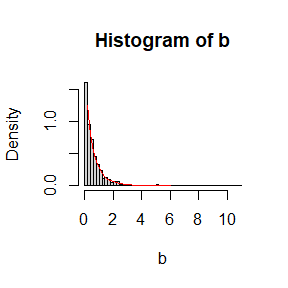

```r
# homework 3.13

rm(list=ls())
set.seed(1234)

# function that generates random numbers
generate <- function(n) {
    result <- rep(0, n)
    lambda <- rgamma(n=n, shape=4, rate=2)
    result <- rexp(n=n, rate=lambda)
    result
}

b <- generate(1000)
x <- seq(0.2, 6, 0.2)
y <- 64*(2+x)^(-5)

# draw histogram and line
hist(b, freq=F, breaks=50)
lines(x, y, col="red")
```

# HOMEWORK 3

## 5.3

Theoretical computation:
$$\begin{aligned}
\int_0^{\pi/3}\sin{x}\mathrm{d}x &=(-\cos{x})|^{\pi/3}_0\\
&=-\frac12-(-1)\\
&=\frac12
\end{aligned}$$
Use Monte-Carlo method to compute the integration.

```r
rm(list=ls())
set.seed(111)
# generate random numbers
u <- runif(1e5, 0, pi/3)

# use Monte-Carlo method to compute the integration
y <- sin(u)
value <- pi/3*mean(y); value
```

```
# [1] 0.4994595
```

## 5.7

Use Monte-Carlo method and Antithetic method to compute the integration respectively. And compare the empirical variance of the two methods.

```r
rm(list=ls())
set.seed(111)

# @Function used to compute integration
# @Param anti:  if anti=TRUE use "Antithetic" method
#               otherwise use "Monte-Carlo" method.
# @Param n:     number of random variates we generate
rate.phi <- function(n, anti=TRUE) {
    u <- runif(n/2)
    if(anti) u <- c(u, 1-u) else u <- c(u, runif(n/2))
    x <- exp(u)
    value1 <- mean(x)
    value1
}

m <- 1e3
MC1 <- rep(0., m)
MC2 <- rep(0., m)

for(i in 1:m) {
    MC1[i] <- rate.phi(1e3)
    MC2[i] <- rate.phi(1e3, anti=FALSE)
}

# empirical percent reduction in variance using antithetic variate
c(mean(MC1), mean(MC2), var(MC1)/var(MC2))
```

```
# [1] 1.71831521 1.71797868 0.03443972
```

### Theoretical computation

Compute $\mathbf{Cov}(e^u, e^{1-u})$:
$$\mathbf{Cov}(e^u,e^{1-u})=E[e^ue^{1-u}]-E[e^u]E[e^{1-u}]=e-(e-1)^2=-e^2+3e-1$$

Compute $\mathbf{Var}((e^u+e^{1-u})/2)$

$$\mathbf{Var}(e^u)=E[e^{2u}]-E^2[e]=\int_0^1e^{2u}\mathrm{d}u-(e-1)^2=\frac12(-e^2+4e-3)$$

$$\begin{aligned}
\mathbf{Var}(e^u+e^{1-u}) &=\mathbf{Var}(e^u)+\mathbf{Var}(e^{1-u})+2\mathbf{Cov}(e^u,e^{1-u})\\
&= 2\mathbf{Var}(e^u)+2\mathbf{Cov}(e^u,e^{1-u})\\
&= -3e^2+10e-5
\end{aligned}$$

Theoretical percent ruduction in variance:
$$\frac{\mathbf{Var}((e^u+e^{1-u})/2)}{\mathbf{Var}(e^u)}=\frac{-3e^2+10e-5}{-2e^2+8e-6}$$

```r
e <- 2.718281828
theo.rate <- (-3*e^2+10*e-5)/(-2*e^2+8*e-6); theo.rate
```

```
# [1] 0.01616497
```

## 5.11

It is easy to compute:

$$\mathbf{Var}(c\hat{\theta}_1+(1-c)\hat{\theta}_2)=c^2\mathbf{Var}(\hat{\theta}_1-\hat{\theta}_2)+2c\mathbf{Cov}(\hat{\theta}_2,\hat{\theta}_1-\hat{\theta}_2)+\mathbf{Var}(\hat{\theta}_2)$$

This is a quadratic function of $c$, hence:

$$c^*=-\frac{\mathbf{Cov}(\hat{\theta}_2,\hat{\theta}_1-\hat{\theta}_2)}{\mathbf{Var}(\hat{\theta}_1-\hat{\theta}_2)}=\frac{\mathbf{Var}(\hat{\theta}_2)-\mathbf{Cov}(\hat{\theta}_2,\hat{\theta}_1)}{\mathbf{Var}(\hat{\theta}_1)+\mathbf{Var}(\hat{\theta}_2)-2\mathbf{Cov}(\hat{\theta}_2,\hat{\theta}_1)}$$

# HOMEWORK 4

## Question

### 5.13

Find two importance functions $f_1$ and $f_2$ that are supported on $(1,+\infty)$ and are ‘close’ to
$$g(x) = \frac{x^2}{\sqrt{2\pi}} e^{-\frac{x^2}2}, x > 1.$$
Which of your two importance functions should produce the smaller variance in estimating
$$\int_1^\infty\frac{x^2}{\sqrt{2\pi}} e^{-\frac{x^2}2}\mathrm{d}x$$
by importance sampling? Explain.

### 5.15

Obtain the stratified importance sampling estimate in Example 5.13 and compare it with the result of Example 5.10.

### 6.4

Suppose that $X_1,\dots, X_n$ are a random sample from a from a lognormal distribution with unknown parameters. Construct a $95\%$ confidence interval for the parameter $\mu$. Use a Monte Carlo method to obtain an empirical estimate of the confidence level.

### 6.5

Suppose a $95\%$ symmetric t-interval is applied to estimate a mean, but the sample data are non-normal. Then the probability that the confidence interval covers the mean is not necessarily equal to $0.95$. Use a Monte Carlo experiment to estimate the coverage probability of the t-interval for random samples of $\chi^2(2)$ data with sample size $n = 20$. Compare your t-interval results with the simulation results in Example 6.4. (The t-interval should be more robust to departures from normality than the interval for variance.)

## Answer

### 5.13

chose
$$f_1(x)=\frac2{\sqrt{2{\pi}}}e^{-\frac{(x-1)^2}{2}}, x>1$$

$$\frac{g(x)}{f_1(x)}=\frac{x^2}2e^{-x+\frac12},x>1$$

chose
$$f_2(x)=e^{-(x-1)}, x>1$$

$$\frac{g(x)}{f_2(x)}=\frac{1}{\sqrt{2\pi}}x^2e^{-\frac{x^2}2+x-1},x>1$$

From our simulation, it`s obvious that the chose $f_1$ as importance function we can get a smaller variance. It is the first importance function curve closer to $g(x)$.

```r
rm(list=ls())
set.seed(123)
g <- function(x) {
    1/sqrt(2*pi)*(x^2)*exp(-0.5*(x^2))*(x>1)
}

f1 <- function(x) {
    2/sqrt(2*pi)*exp(-0.5*(x^2)+x-0.5)*(x>1)
}

f2 <- function(x) {
    exp(-(x-1))*(x>1)
}

n <- 1e4
# generate samples from distribution f1
u <- abs(rnorm(n))+1
fg1 <-g(u)/f1(u)
# generate samples from distribution f2
v <- rexp(n,1)+1
fg2 <- g(v)/f2(v)

# estimation use importance function f1
mean(fg1)
```

```
# [1] 0.4003573
```

```r
# estimation use importance function f2
mean(fg2)
```

```
# [1] 0.4013249
```

```r
# the variance of the two estimations
var(fg1)
```

```
# [1] 0.00195779
```

```r
var(fg2)
```

```
# [1] 0.02513175
```

### 5.15

simply divide the interval $[0,1]$ into 5 parts. Then on the $j_{th}$ subinterval variables are generated from the density:
$$f_k(x)=\frac{C_k}{1-e^{-1}}e^{-x},\frac{k-1}5<x<\frac k5$$
$C_1=$ 3.4871914,$C_2=$ 4.2592652,$C_3=$ 5.2022783,$C_4=$ 6.354077,$C_5=$ 7.7608872

Our integration can be write as:

$$\int_0^1 g(x)\mathrm{d}x=\sum_{k=1}^5\int_{(k-1)/5}^{k/5} \frac{g(x)}{f_k(x)}f_k(x)d(x)$$
.

```r
rm(list=ls())
set.seed(7)
g <- function(x) {
    exp(-x - log(1+x^2)) * (x > 0) * (x < 1)
}

f <- function(x, k) {
    C <- (1-exp(-1))/(exp(-0.2*k+0.2)-exp(-0.2*k))
    C/(1-exp(-1))*exp(-x)*(x>(0.2*k-0.2))*(x<(0.2*k))
}

rf <- function(m, k) {
    C <- (1-exp(-1))/(exp(-0.2*k+0.2)-exp(-0.2*k))
    u <- runif(m)
    x <- -log(exp(-0.2*k+0.2)-u*(1-exp(-1))/C)
    x
}

m=2e4
theta <- numeric(5)
var.theta <- numeric(5)
for (k in 1:5){
    v <- rf(m, k)
    xx <- g(v)/f(v,k)
    theta[k] <- mean(xx)
    var.theta[k] <- var(xx)
}

# stratified importance sampling
sum(theta)
```

```
# [1] 0.5248173
```

```r
5*sum(var.theta)
```

```
# [1] 0.0003123022
```

```r
# importance sampling
u <- runif(5*m) #inverse transform method
x <- - log(1 - u * (1 - exp(-1)))
fg <- g(x) / (exp(-x) / (1 - exp(-1)))

mean(fg)
```

```
# [1] 0.5244793
```

```r
var(fg)
```

```
# [1] 0.009396823
```

### 6.4

If $X\sim LN(\mu, \sigma^2)$, it`s easy to know that $\log{X}\sim N(\mu, \sigma^2)$. If $X_1,X_2,\dots,X_n,iid\sim LN(\mu,\sigma^2)$, let $Y_i=\log{X_i}$
$$(\bar{Y}-\mu)/\hat{\sigma}\sim t_{n-1}$$
$\hat{\sigma}^2=\frac1{n-1}\sum_{i=1}^n(Y_i-\bar{Y})^2$, $\bar{Y}=\frac1n\sum_{i=1}^nY_i$ so the $1-\alpha$ confidence interval of $\mu$ is:
$$[\bar{Y}-\hat{\sigma}t_{n-1}(1-\alpha/2), \bar{Y}+\hat{\sigma}t_{n-1}(1-\alpha/2)]$$

```r
rm(list=ls())
set.seed(123)
n <- 20
m <- 1e4
mu <- 1
sigma <- 1
alpha <- 0.05
u <- numeric(n)
theta.hat <-data.frame(L=numeric(m), U=numeric(m))

for (i in 1:m) {
    u <- rlnorm(n, mu, sigma)
    x <- log(u)
    len <- sd(x)*qt(1-alpha/2, n-1)
    theta.hat[i, 1:2] <- c(mean(x)-len,mean(x)+len)
}

# 95% confidence interval of parameter mu
# use Monte-Carlo method
apply(theta.hat,2,mean)
```

```
#         L         U
# -1.067428  3.073620
```

### 6.5

Generate some samples from $\chi^2(2)$, compute the t-interval. Then generate samples from $\chi^2(2)$, compute the frequency of samples in the t-interval. Repeat the process m times, and the average of these frequencies is the Monte-Carlo coverage probability.

```r
rm(list=ls())
set.seed(123)

n <- 100
m <- 1e4
alpha <-0.05

x <- rchisq(n, 2)
len <- sd(x)*qt(1-alpha/2, n-1)
# t-interval
L <- mean(x)-len; L
```

```
# [1] -1.855659
```

```r
U <- mean(x)+len; U
```

```
# [1] 5.464159
```

```r
p.hat <-numeric(m)

for (i in 1:m) {
    # generate samples from chi-square distribution with df=2
    u <- rchisq(n, 2)
    # frequency elements of u in [L, U]
    p.hat[i] <- sum((u>=L)*(u<=U))/n
}

# coverage probability of the t-interval
mean(p.hat)
```

```
# [1] 0.934834
```

# HOMEWORK 5

## Question

### 6.7

Estimate the power of the skewness test of normality against symmetric $Beta(\alpha, \alpha)$ distributions and comment on the results. Are the results different for heavy-tailed symmetric alternatives such as $t(\nu)$?

### 6.8

Refer to Example 6.16. Repeat the simulation, but also compute the $F$ test of equal variance, at significance level $\hat{\alpha}=0.055$. Compare the power of the Count Five test and $F$ test for small, medium, and large sample sizes. (Recall that the $F$ test is not applicable for non-normal distributions.)

### 6.C

Repeat Examples 6.8 and 6.10 for Mardia’s multivariate skewness test. Mardia [187] proposed tests of multivariate normality based on multivariate generalizations of skewness and kurtosis. If $X$ and $Y$ are iid, the multivariate population skewness $\beta_{1,d}$ is defined by Mardia as
$$\beta_{1,d}=E[(X-\mu)^T\Sigma^{-1}(Y-\mu)]^3$$
Under normality, $\beta_{1,d}=0$. The multivariate skewness statistic is
$$b_{1,d}=\frac1{n^2}\sum_{i,j}^n\bigg[(X_i-\bar{X})^T\hat{\Sigma}^{-1}(X_j-\bar{X})\bigg]^3$$
where $\hat{\Sigma}$ is the maximum likelihood estimator of covariance. Large values of $b_{1,d}$ are significant. The asymptotic distribution of $nb_{1,d}/6$ is chisquared with $d(d + 1)(d + 2)/6$ degrees of freedom.

### Discussion

If we obtain the powers for two methods under a particular simulation setting with 10,000 experiments: say, 0.651 for one method and 0.676 for another method. Can we say the powers are different at 0.05 level?

1. What is the corresponding hypothesis test problem?
2. What test should we use? Z-test, two-sample t-test, paired-t test or McNemar test?
3. What information is needed to test your hypothesis?

## Answer

### 6.7

```r
rm(list=ls())

sk <- function(x) {
    #computes the sample skewness coeff.
    xbar <- mean(x)
    m3 <- mean((x - xbar)^3)
    m2 <- mean((x - xbar)^2)
    return( m3 / m2^1.5 )
}

alpha <- .05
n <- 30
m <- 2500

pwr <- numeric(2)
#critical value for the skewness test
cv <- qnorm(1-alpha/2, 0, sqrt(6*(n-2) / ((n+1)*(n+3))))

sktests <- numeric(m)
for (i in 1:m) { #for each replicate
    x <- rbeta(n, 4, 4)
    sktests[i] <- as.integer(abs(sk(x)) >= cv)
}
# power of the skewness test of normality
# against beta(4, 4)
pwr[1] <- mean(sktests)

for (i in 1:m) { #for each replicate
    x <- rt(n, 8)
    sktests[i] <- as.integer(abs(sk(x)) >= cv)
}
# power of the skewness test of normality
# against t(8)
pwr[2] <- mean(sktests)
pwr
```

```
# [1] 0.016 0.160
```

### 6.8

For different sample size, estimate the powers of `count5test()` and `f.test()`. From our result, the power of F test is larger than that of count5test.

```r
rm(list=ls())

count5test <- function(x, y) {
    X <- x - mean(x)
    Y <- y - mean(y)
    outx <- sum(X > max(Y)) + sum(X < min(Y))
    outy <- sum(Y > max(X)) + sum(Y < min(X))
    # return 1 (reject) or 0 (do not reject H0)
    return(as.integer(max(c(outx, outy)) > 5))
}

f.test <- function(x, y, alpha=0.055) {
    N <- length(x)
    M <- length(y)
    F <- var(x)/var(y)
    (F < qf(alpha/2, N-1, M-1))||(F>qt(1-alpha/2, N-1, M-1))
}

m <- 1e3
# sample size for small, medium, large
n <- c(10, 50, 1e3)
# generate samples under H1 to estimate power
sigma1 <- 1
sigma2 <- 1.5
power <- matrix(0, ncol=2,nrow=3)

for (j in 1:3){
    power[j,1] <- mean(replicate(m, expr={
        x <- rnorm(n[j], 0, sigma1)
        y <- rnorm(n[j], 0, sigma2)
        count5test(x, y)
    }))

    power[j, 2] <- mean(replicate(m, expr={
        x <- rnorm(n[j], 0, sigma1)
        y <- rnorm(n[j], 0, sigma2)
        f.test(x, y)
    }))
}

power
```

```
#       [,1]  [,2]
# [1,] 0.117 0.195
# [2,] 0.663 0.827
# [3,] 0.997 1.000
```

### 6.C

Implement the Mardia test function, and replace `sk()` with `mardia.test()`. Since their distributions are different, we should compare the p-value with test level $\alpha$ when we use `mardia.test()`.

```r
rm(list=ls())
library(MASS)
# set.seed(124)
mardia.test <- function(x,alpha=0.05) {
    m <- nrow(x)
    p <- ncol(x)
    var.hat <- var(x)*(m-1)/m
    inve <- solve(var.hat)
    ave <- apply(x, 2, mean)
    mat <- matrix(rep(ave, m), ncol=p,byrow = TRUE)
    x <- x-mat
    S <- x%*%inve%*%t(x)
    M <- sum(S^3)/(m*6)
    degree <- p*(p+1)*(p+2)/6
    pchisq(M, degree)
}

n <- c(10, 20, 30, 50, 100, 500) # sample sizes
alpha <- 0.05 #
p.reject <- numeric(length(n)) # to store sim. results
mm <- 1000 # num. repl. each sim.
for (i in 1:length(n)) {
    sktests <- numeric(mm) # test decisions
    for (j in 1:mm) {
        x <- as.matrix(mvrnorm(n[i], c(0,0),matrix(c(1,0.3,0.3,1.5),ncol=2)))
        # test decision is 1 (reject) or 0
        sktests[j] <- ((mardia.test(x)) >= (1-alpha) )
    }
    p.reject[i] <- mean(sktests) # proportion rejected
}
p.reject
```

```
# [1] 0.005 0.029 0.029 0.039 0.055 0.048
```

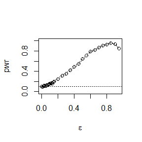

```r
rm(list=ls())
library(MASS)
mardia.test <- function(x,alpha=0.05) {
    m <- nrow(x)
    p <- ncol(x)
    # mle of covariance matrix
    var.hat <- var(x)*(m-1)/m
    inve <- solve(var.hat)
    ave <- apply(x, 2, mean)
    mat <- matrix(rep(ave, m), ncol=p,byrow = TRUE)
    x <- x-mat
    S <- x%*%inve%*%t(x)
    # compute mardia statistic
    M <- sum(S^3)/(m*6)
    # degree of freedom of asymptotic distribution
    degree <- p*(p+1)*(p+2)/6
    # p-value of the mardia statistic
    pchisq(M, degree)
}

alpha <- .1
n <- 100
mm <- 1000
epsilon <- c(seq(0.0, .15, .01), seq(.15, 0.95, .05))
N <- length(epsilon)
pwr <- numeric(N)
#critical value for the skewness test

for (j in 1:N) { #for each epsilon
    e <- epsilon[j]
    sktests <- numeric(mm)
    for (i in 1:mm) { #for each replicate
        sig <- sample(c(0, 1), replace = TRUE, size = n, prob = c(1-e, e))
        n1 <- sum(sig)
        n2 <- n - n1
        x1 <- mvrnorm(n, c(0,0),matrix(c(1,0.3,0.3,1.5),ncol=2))
        x2 <- mvrnorm(n, c(0,0), matrix(c(10,0.3,0.3,15),ncol=2))
        x <- rbind(x1[1:n1,],x2[1:n2,])
        sktests[i] <- ((mardia.test(x)) >= 1-alpha)
    }
    pwr[j] <- mean(sktests)
}
#plot power vs epsilon
plot(epsilon, pwr, type = "b",
     xlab = bquote(epsilon), ylim = c(0,1))
abline(h = .1, lty = 3)
se <- sqrt(pwr * (1-pwr) / mm) #add standard errors
lines(epsilon, pwr+se, lty = 3)
lines(epsilon, pwr-se, lty = 3)
```

### Discussion

-1 The corresponding test is:

$H_0$:the powers are same $H_1$:the powers are different

-2 We should use paired t-test.

-3 We need the data in each experiment whether the two tests reject the null hypothesis. 1 denotes reject the null hypothesis and 0 denotes don`t reject the null hypothesis. If we have these data for the two tests stored in $X$ and $Y$, we can use paired t-test.

```r
rm(list=ls())
n <- 1e4

X <- sample(c(0, 1), size=n, replace = TRUE, prob=c(0.349, 0.651))
Y <- sample(c(0, 1), size=n, replace = TRUE, prob=c(0.324, 0.676))
minu <- (X-Y)
t.test(minu,conf.level=0.95)
```

```
#
#   One Sample t-test
#
# data:  minu
# t = -4.8577, df = 9999, p-value = 1.206e-06
# alternative hypothesis: true mean is not equal to 0
# 95 percent confidence interval:
#  -0.04575501 -0.01944499
# sample estimates:
# mean of x
#   -0.0326
```

# HOMEWORK 6

## Question

### 7.1

Compute a jackknife estimate of the bias and the standard error of the correlation statistic in Example 7.2.

### 7.5

Refer to Exercise 7.4. Compute $95\%$ bootstrap confidence intervals for the mean time between failures $1/\lambda$ by the standard normal, basic, percentile, and BCa methods. Compare the intervals and explain why they may differ.

### 7.8

Refer to Exercise 7.7. Obtain the jackknife estimates of bias and standard error of $\hat\theta$.

### 7.11

In Example 7.18, leave-one-out (n-fold) cross validation was used to select the best fitting model. Use leave-two-out cross validation to compare the models.

## Answer

### 7.1

Compute a jackknife estimate of the bias and the standard error of the correlation statistic.

```r
library(bootstrap)
n <- nrow(law)
theta.jack <- numeric(n)

for (i in 1:n) {
    data <- law[-i,]
    theta.jack[i] <- cor(data[,1],data[,2])
}

theta.hat <- cor(law[,1],law[,2])

# estimate bias of theta.hat using jackknife method
bias.jack <- (n-1)*(mean(theta.jack)-theta.hat); round(bias.jack,4)
```

```
# [1] -0.0065
```

```r
# estimate standard error of theta.hat using jackknife method
se.jack <- sqrt((n-1)^2*var(theta.jack)/n); round(se.jack,4)
```

```
# [1] 0.1425
```

### 7.5

Since $E[X]=\frac 1{\lambda}$, we can estimate $\lambda$ using $\hat\lambda=1/{\bar X}$. Then compute the $95\%$ bootstrap confidence interval.

```r
library(boot)
set.seed(123)
data <- aircondit
alpha <- 0.05

N <- 1e3

est <- function(dat, ind) {
    1/mean(dat[ind,1])
}

boot.obj <- boot(data=data,statistic = est,R=N)
boot.ci(boot.obj,conf=1-alpha,type=c("basic", "norm", "perc", "bca"))
```

```
# BOOTSTRAP CONFIDENCE INTERVAL CALCULATIONS
# Based on 1000 bootstrap replicates
#
# CALL :
# boot.ci(boot.out = boot.obj, conf = 1 - alpha, type = c("basic",
#     "norm", "perc", "bca"))
#
# Intervals :
# Level      Normal              Basic
# 95%   (-0.0005,  0.0160 )   (-0.0024,  0.0131 )
#
# Level     Percentile            BCa
# 95%   ( 0.0055,  0.0209 )   ( 0.0047,  0.0178 )
# Calculations and Intervals on Original Scale
# Some BCa intervals may be unstable
```

These methods are different because the distribution of statistics they use are different.

### 7.8

Obtain the jackknife estimates of bias and standard error of $\hat\theta$.

```r
rm(list=ls())
library(bootstrap)
data <- scor

estim <- function (dat) {
  n <- nrow(dat)
  sig <- (n-1)*var(dat)/n
  vs <- eigen(sig)
  lambdas <- vs$values
  lambdas[1]/sum(lambdas)
}

n <- nrow(data)
theta.hat <- estim(data)
theta.jack <- numeric(n)
for (i in 1:n) {
  x <- data[-i,]
    theta.jack[i] <- estim(x)
}

# estimate the bias of theta.hat using jackknife method
bias.jack <- (n-1)*(mean(theta.jack)-theta.hat); round(bias.jack,4)
```

```
# [1] 0.0011
```

```r
# estimate the standard error using jackknife method
se.jack <- sqrt((n-1)^2*var(theta.jack)/n); round(se.jack,4)
```

```
# [1] 0.0496
```

### 7.11

Divide the data set into $N$ groups which makes every group contain two data points. Leave one group out and use the other $N-1$ groups to train.

```r
rm(list=ls())
library(DAAG); attach(ironslag)
a <- seq(10, 40, .1) #sequence for plotting fits
L1 <- lm(magnetic ~ chemical)
yhat1 <- L1$coef[1] + L1$coef[2] * a

L2 <- lm(magnetic ~ chemical + I(chemical^2))
yhat2 <- L2$coef[1] + L2$coef[2] * a + L2$coef[3] * a^2

L3 <- lm(log(magnetic) ~ chemical)
logyhat3 <- L3$coef[1] + L3$coef[2] * a
yhat3 <- exp(logyhat3)

L4 <- lm(log(magnetic) ~ log(chemical))
logyhat4 <- L4$coef[1] + L4$coef[2] * log(a)

n <- length(magnetic) #in DAAG ironslag

# divide the data into to N groups
# each group contains two data point
N <- round(n/2)
e1 <- e2 <- e3 <- e4 <- matrix(0, nrow=N, ncol=2)
num <- matrix(sample(1:n,2*N),ncol=2,nrow=N)

# for N-fold cross validation
# fit models on leave-two-out samples
for (k in 1:N) {
    y <- magnetic[-num[k,]]
    x <- chemical[-num[k,]]
    J1 <- lm(y ~ x)
    yhat1 <- J1$coef[1] + J1$coef[2] * chemical[num[k,]]
    e1[k,] <- magnetic[num[k]] - yhat1
    J2 <- lm(y ~ x + I(x^2))
    yhat2 <- J2$coef[1] + J2$coef[2] * chemical[num[k,]] +
        J2$coef[3] * chemical[num[k,]]^2
    e2[k,] <- magnetic[num[k,]] - yhat2
    J3 <- lm(log(y) ~ x)
    logyhat3 <- J3$coef[1] + J3$coef[2] * chemical[num[k,]]
    yhat3 <- exp(logyhat3)
    e3[k,] <- magnetic[num[k,1]] - yhat3
    J4 <- lm(log(y) ~ log(x))
    logyhat4 <- J4$coef[1] + J4$coef[2] * log(chemical[num[k,]])
    yhat4 <- exp(logyhat4)
    e4[k,] <- magnetic[num[k,]] - yhat4
}
lapply(list(e1,e2,e3,e4), function(x) {
  a <- apply(x^2,1,sum)
  mean(a)
})
```

```
# [[1]]
# [1] 87.01746
#
# [[2]]
# [1] 36.93266
#
# [[3]]
# [1] 78.57753
#
# [[4]]
# [1] 41.2837
```

```r
detach(ironslag)
```

According to the prediction error criterion, Model 2, the quadratic model, would be the best fit for the data.

# HOMEWORK 7

## Question

### 1.

The Count 5 test for equal variances in Section 6.4 is based on the maximum number of extreme points. Example 6.15 shows that the Count 5 criterion is not applicable for unequal sample sizes. Implement a permutation test for equal variance based on the maximum number of extreme points that applies when sample sizes are not necessarily equal.

### 2.

Design experiments for evaluating the performance of the NN, energy, and ball methods in various situations.

1. Unequal variances and equal expectations
2. Unequal variances and unequal expectations
3. Non-normal distributions: t distribution with 1 df (heavy-tailed distribution), bimodel distribution (mixture of two normal distributions)
4. Unbalanced samples (say, 1 case versus 10 controls)

Note: The parameters should be chosen such that the powers are distinguishable (say, range from 0.3 to 0.8).

## Answer

### 1.

Use permutation method to promote count5 test.

```r
rm(list=ls())
set.seed(1234)
count5test <- function(x, y) {
    X <- x - mean(x)
    Y <- y - mean(y)
    outx <- sum(X > max(Y)) + sum(X < min(Y))
    outy <- sum(Y > max(X)) + sum(Y < min(X))
    # return 1 (reject) or 0 (do not reject H0)
    return(as.integer(max(c(outx, outy)) > 5))
}

permutation <- function(z, R=1e3) {
    N = length(z)
    s = replicate(R,{
    idx = sample(1:N, N/2, replace = FALSE)
    x = z[idx]
    y = z[-idx]
    count5test(x,y)
    })
    mean(s)
}

n1 <- 50
n2 <- 20
N <- n1 + n2
mu1 <- mu2 <- 0
sigma1 <- 1
sigma2 <- 1
m <- 1e3

# use permutation
permutation.test <- replicate(m, expr = {
    x <- rnorm(n1, mu1, sigma1)
    y <- rnorm(n2, mu2, sigma2)
    x <- x - mean(x)
    y <- y - mean(y)
    z <- c(x, y)
    permutation(z)
} )

count5.test <- replicate(m, expr = {
    x <- rnorm(n1, mu1, sigma1)
    y <- rnorm(n2, mu2, sigma2)
    x <- x - mean(x)
    y <- y - mean(y)
    count5test(x,y)
} )


mean(permutation.test<0.05)
```

```
# [1] 0.037
```

```r
mean(count5.test)
```

```
# [1] 0.313
```

### 2.

evaluating the performance of the NN, energy, and ball methods in various situations. Use unequal variances, unequal variances and unequal expectations, t-distribution and bimodel distribution, unbalanced samples.

```r
rm(list=ls())
library(energy); library(Ball); library(boot)
library(MASS); library(RANN)
set.seed(12345)

Tn <- function(z, ix, sizes,k) {
    n1 <- sizes[1]; n2 <- sizes[2]; n <- n1 + n2
    if(is.vector(z)) z <- data.frame(z,0);
    z <- z[ix, ];
    NN <- nn2(data=z, k=k+1) # what's the first column?
    block1 <- NN$nn.idx[1:n1,-1]
    block2 <- NN$nn.idx[(n1+1):n,-1]
    i1 <- sum(block1 < n1 + .5); i2 <- sum(block2 > n1+.5)
    (i1 + i2) / (k * n)
}

eqdist.nn <- function(z,sizes,k){
    boot.obj <- boot(data=z,statistic=Tn,R=R,
                     sim = "permutation", sizes = sizes,k=k)
    ts <- c(boot.obj$t0,boot.obj$t)
    p.value <- mean(ts>=ts[1])
    list(statistic=ts[1],p.value=p.value)
}

m <- 100; k<-3; p<-2; mu <- 0.5
R<-999;alpha <- 0.05;
n <- seq(10,100,10);


# Unequal variances and equal expectations
p.values <- matrix(NA,m,3)
pows <- matrix(NA, length(n), 3)

for (k in 1:length(n)){
    for(i in 1:m){
        n1<-n2<- n[k]
        N <- c(n1,n2)
        x <- mvrnorm(n1, mu=c(0,0), Sigma=diag(c(3,2)))
        y <- mvrnorm(n2, mu=c(0,0), Sigma=diag(c(1,1)))
        z <- rbind(x,y)
        p.values[i,1] <- eqdist.nn(z,N,k)$p.value
        p.values[i,2] <- eqdist.etest(z,sizes=N,R=R)$p.value
        p.values[i,3] <- bd.test(x=x,y=y,R=999,seed=i*12345)$p.value
    }
    pows[k,1:3] = colMeans(p.values<alpha)
}


plot(n, pows[1:10,1], type = "b", pch=20, col='red', lwd=1)
lines(n, pows[1:10,2], type='b',lty=2, col='blue')
lines(n, pows[1:10,3], type='b',lty=2,col='green')

# Unequal variances and unequal expectations
pow2 <- matrix(NA, length(n), 3)
p.values2 <- matrix(NA, m, 3)
for (k in 1:length(n)){
    for(i in 1:m){
        n1<-n2<- n[k]
        N <- c(n1,n2)
        x <- mvrnorm(n1, mu=c(1,0.5), Sigma=diag(c(3,2)))
        y <- mvrnorm(n2, mu=c(0,0), Sigma=diag(c(1,1)))
        z <- rbind(x,y)
        p.values2[i,1] <- eqdist.nn(z,N,k)$p.value
        p.values2[i,2] <- eqdist.etest(z,sizes=N,R=R)$p.value
        p.values2[i,3] <- bd.test(x=x,y=y,R=999,seed=i*12345)$p.value
    }
    pow2[k,1:3] = colMeans(p.values2<alpha)
}

plot(n, pow2[1:10,1], type = "b", pch=20, col='red', lwd=1)
lines(n, pow2[1:10,2], type='b',lty=2, col='blue')
lines(n, pow2[1:10,3], type='b',lty=2,col='green')


# t-distribution with 1 dim and bimodel distribution
pow3 <- matrix(NA, length(n), 3)
p.values3 <- matrix(NA, m, 3)
for (k in 1:length(n)){
    for(i in 1:m){
        n1<-n2<- n[k]
        N <- c(n1,n2)
        x <- matrix(rt(n1*2,1),ncol=2)
        y1 <- mvrnorm(n2/2, mu=c(0,0), Sigma=diag(c(1,1)))
        y2 <- mvrnorm(n2-n2/2, mu=c(1,0), Sigma=diag(c(1,2)))
        y <- rbind(y1,y2)
        z <- rbind(x,y)
        p.values3[i,1] <- eqdist.nn(z,N,k)$p.value
        p.values3[i,2] <- eqdist.etest(z,sizes=N,R=R)$p.value
        p.values3[i,3] <- bd.test(x=x,y=y,R=999,seed=i*12345)$p.value
    }
    pow3[k,1:3] = colMeans(p.values3<alpha)
}

plot(n, pow3[1:10,1], type = "b", pch=20, col='red', lwd=1)
lines(n, pow3[1:10,2], type='b',lty=2, col='blue')
lines(n, pow3[1:10,3], type='b',lty=2,col='green')


# unbalanced samples
pow4 <- matrix(NA, length(n), 3)
p.values4 <- matrix(NA, m, 3)
for (k in 1:length(n)){
    for(i in 1:m){
        n1<- n[k]/2
        n2<- n[k]
        N <- c(n1,n2)
        x <- mvrnorm(n1, mu=c(0,0), Sigma=diag(c(1,1)))
        y <- mvrnorm(n2, mu=c(1,2), Sigma=diag(c(2,3)))
        z <- rbind(x,y)
        p.values4[i,1] <- eqdist.nn(z,N,k)$p.value
        p.values4[i,2] <- eqdist.etest(z,sizes=N,R=R)$p.value
        p.values4[i,3] <- bd.test(x=x,y=y,R=999,seed=i*12345)$p.value
    }
    pow4[k,1:3] = colMeans(p.values4<alpha)
}

plot(n, pow4[1:10,1],type = "b", pch=20, col='red', lwd=1)
lines(n, pow4[1:10,2], type='b',lty=2, col='blue')
lines(n, pow4[1:10,3], type='b',lty=2,col='green')
```

[output not shown]

# HOMEWORK 8

## Question

### 1.

Implement a random walk Metropolis sampler for generating the standard Laplace distribution (see Exercise 3.2). For the increment, simulate from a normal distribution. Compare the chains generated when different variances are used for the proposal distribution. Also, compute the acceptance rates of each chain.

### 2.

For Exercise 1, use the Gelman-Rubin method to monitor convergence of the chain, and run the chain until it converges approximately to the target distribution according to $\hat{R} < 1.2$.

### 3.

Find the intersection points $A(k)$ in $(0, \sqrt{k})$ of the curves
$$S_{k-1}(a)=P\Bigg(t(k-1)>\sqrt{\frac{a^2(k-1)}{k-a^2}}\Bigg)$$
and
$$S_{k}(a)=P\Bigg(t(k)>\sqrt{\frac{a^2k}{k+1-a^2}}\Bigg),$$
for $k = 4 : 25, 100, 500, 1000$, where $t(k)$ is a Student t random variable with $k$ degrees of freedom.

## Answer

### 1.

```r
rm(list = ls())
set.seed(7)
dlaplace <- function(x) {
    0.5*exp(-abs(x))
}
qlaplace <- function(x) {
    y <- x
    for (i in 1:length(x)) {
        if(x[i]>=0.5) {
            y[i] <- qexp(2*x[i]-1, rate=1)
        }
        else {
            y[i] <- -qexp(1-2*x[i], rate=1)
        }
    }
    return(y)
}

rw.Metropolis <- function(sigma, x0, N) {
    x <- numeric(N)
    x[1] <- x0
    u <- runif(N)
    k <- 0
    for (i in 2:N) {
        y <- rnorm(1, x[i-1], sigma)
        if (u[i] <= (dlaplace(y) / dlaplace(x[i-1])))
            x[i] <- y
        else {
            x[i] <- x[i-1]
            k <- k + 1
        }
    }
    return(list(x=x, k=k))
}

N <- 2000
sigma <- c(.05, .5, 2,  16)

x0 <- 25
rw1 <- rw.Metropolis(sigma[1], x0, N)
rw2 <- rw.Metropolis(sigma[2], x0, N)
rw3 <- rw.Metropolis(sigma[3], x0, N)
rw4 <- rw.Metropolis(sigma[4], x0, N)

#number of candidate points rejected
no.reject <- data.frame(sigma=sigma,no.reject=c(rw1$k, rw2$k, rw3$k, rw4$k))
knitr::kable(no.reject,format='latex')
```

[output not shown]

```r
par(mfrow=c(2,2))  #display 4 graphs together
refline <- qlaplace(c(.025, .975))
rw <- cbind(rw1$x, rw2$x, rw3$x,  rw4$x)
for (j in 1:4) {
    plot(rw[,j], type="l",
            xlab=bquote(sigma == .(round(sigma[j],3))),
            ylab="X", ylim=range(rw[,j]))
    abline(h=refline)
}
par(mfrow=c(1,1)) #reset to default
```

[output not shown]

```r
a <- c(.05, seq(.1, .9, .1), .95)
Q <- qlaplace(a)
rw <- cbind(rw1$x, rw2$x, rw3$x, rw4$x)
mc <- rw[501:N, ]
Qrw <- apply(mc, 2, function(x) quantile(x, a))
qq <- data.frame(round(cbind(Q, Qrw), 3))
names(qq) <- c('True','sigma=0.05','sigma=0.5','sigma=2','sigma=16')
knitr::kable(qq,format='latex',) #latex format
```

[output not shown]

### 2.

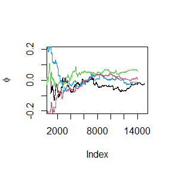

```r
rm(list=ls())
Gelman.Rubin <- function(psi) {
    # psi[i,j] is the statistic psi(X[i,1:j])
    # for chain in i-th row of X
    psi <- as.matrix(psi)
    n <- ncol(psi)
    k <- nrow(psi)

    psi.means <- rowMeans(psi)     #row means
    B <- n * var(psi.means)        #between variance est.
    psi.w <- apply(psi, 1, "var")  #within variances
    W <- mean(psi.w)               #within est.
    v.hat <- W*(n-1)/n + (B/n)     #upper variance est.
    r.hat <- v.hat / W             #G-R statistic
    return(r.hat)
}


dlaplace <- function(x) {
    #Laplace p.d.f.
      0.5*exp(-abs(x))
}

laplace.chain <- function(sigma, N, X1) {
    #generates a Metropolis chain for Laplace
    #with Normal(X[t], sigma) proposal distribution
    #and starting value X1
    x <- rep(0, N)
    x[1] <- X1
    u <- runif(N)

    for (i in 2:N) {
        xt <- x[i-1]
        y <- rnorm(1, xt, sigma)     #candidate point
        r1 <- dlaplace(y) * dnorm(xt, y, sigma)
        r2 <- dlaplace(xt) * dnorm(y, xt, sigma)
        r <- r1 / r2
        if (u[i] <= r) x[i] <- y else
                x[i] <- xt
    }
        return(x)
}

sigma <- 1     #parameter of proposal distribution
k <- 4          #number of chains to generate
n <- 15000      #length of chains
b <- 1000       #burn-in length

    #choose overdispersed initial values
x0 <- c(-10, -5, 5, 10)

#generate the chains
set.seed(12345)
X <- matrix(0, nrow=k, ncol=n)
for (i in 1:k)
    X[i, ] <- laplace.chain(sigma, n, x0[i])

#compute diagnostic statistics
psi <- t(apply(X, 1, cumsum))
for (i in 1:nrow(psi))
    psi[i,] <- psi[i,] / (1:ncol(psi))

#plot psi for the four chains
#par(mfrow=c(2,2))
for (i in 1:k)
    if(i==1){
        plot((b+1):n,psi[i, (b+1):n],ylim=c(-0.2,0.2), type="l",
            xlab='Index', ylab=bquote(phi))
      }else{
        lines(psi[i, (b+1):n], col=i)
    }
```

```r
par(mfrow=c(1,1)) #restore default
```

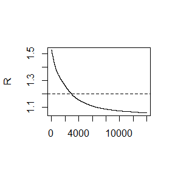

```r
#plot the sequence of R-hat statistics
rhat <- rep(0, n)
for (j in (b+1):n)
    rhat[j] <- Gelman.Rubin(psi[,1:j])
plot(rhat[(b+1):n], type="l", xlab="", ylab="R")
abline(h=1.2, lty=2)
```

### 3.

We can do some computation to simplify the question.
$$\begin{aligned}
S_{k-1}(a)=P\Bigg(t(k-1)>\sqrt{\frac{a^2(k-1)}{k-a^2}}\Bigg)=&
\frac{2 \Gamma\left(\frac{k}{2}\right)}{\sqrt{\pi(k-1)} \Gamma\left(\frac{k-1}{2}\right)} \int_{0}^{c_{k-1}}\left(1+\frac{u^{2}}{k-1}\right)^{-k / 2} d u \\
=& \frac{2 \Gamma\left(\frac{k+1}{2}\right)}{\sqrt{\pi k} \Gamma\left(\frac{k}{2}\right)} \int_{0}^{c_{k}}\left(1+\frac{u^{2}}{k}\right)^{-(k+1) / 2} d u
\end{aligned}$$
for
$$c_{k} =\sqrt{\frac{a^{2} k}{k+1-a^{2}}}$$

```r
rm(list=ls())

inte.fun <- function(a,k){
 ck <- sqrt(a^2*k/(k+1-a^2))
 part1 <- integrate(function(u){(1+u^2/k)^(-(k+1)/2)},0,ck)$value
 part2 <- 2/sqrt(pi*k)*exp(lgamma((k+1)/2)-lgamma(k/2))
 part1*part2
}

root.solve <- function(k){
  output = uniroot(function(a){inte.fun(a,k)-inte.fun(a,k-1)},lower=1,upper=2)
  output$root
}

k <- c(4,25,100,500,1000)
roots <- matrix(0,2,length(k))

for (i in 1:length(k)){
  roots[2,i] <- round(root.solve(k[i]),4)
}

roots[1,] <- k
rownames(roots) <- c('df','root')
roots
```

```
#        [,1]    [,2]     [,3]     [,4]      [,5]
# df   4.0000 25.0000 100.0000 500.0000 1000.0000
# root 1.4921  1.6874   1.7206   1.7298    1.7309
```

# HOMEWORK 9

## Question

### 1.

A-B-O blood type problem I Let the three alleles be A, B, and O.

| Genotype | AA | BB | OO | AO | BO | AB | Sum |
| --- | --- | --- | --- | --- | --- | --- | --- |
| Frequency | $p^2$ | $q^2$ | $r^2$ | $2pr$ | $2qr$ | $2pq$ | $1$ |
| Count | $n_{AA}$ | $n_{BB}$ | $n_{OO}$ | $n_{AO}$ | $n_{BO}$ | $n_{AB}$ | $n$ |

I Observed data: $n_{A\cdot} = n_{AA} + n_{AO} = 444$ (A-type), $n_{B\cdot} = n_{BB} + n_{BO}=132$(B-type), $n_{OO} = 361$ (O-type), $n_{AB} = 63$ (AB-type). I Use EM algorithm to solve MLE of p and q (consider missing data $n_{AA}$ and $n_{BB}$). I Record the values of p and q that maximize the conditional likelihood in each EM steps, calculate the corresponding log-maximum likelihood values (for observed data), are they increasing

### 2.

Use both for loops and `lapply()` to fit linear models to the mtcars using the formulas stored in this list:

```r
formulas <- list(
    mpg ~ disp,
    mpg ~ I(1 / disp),
    mpg ~ disp + wt,
    mpg ~ I(1 / disp) + wt
)
```

### 3.

(1). The following code simulates the performance of a t-test for non-normal data. Use `sapply()` and an anonymous function to extract the p-value from every trial.

```r
trials <- replicate(
    100,
    t.test(rpois(10, 10), rpois(7, 10)),
    simplify = FALSE
)
```

(2). Implement a combination of `Map()` and `vapply()` to create an `lapply()` variant that iterates in parallel over all of its inputs and stores its outputs in a vector (or a matrix). What arguments should the function take?

## Answer

### 1.

```r
rm(list=ls())
library(nloptr)

mle.fun <- function(x,y,n.A=444,n.B=132,nOO=361,nAB=63) {
  r1 = 1-sum(y); r = 1-sum(x)
  nBB = n.B*y[2]^2/(2*y[2]*r1+y[2]^2); nAA = n.A*y[1]^2/(y[1]^2+2*y[1]*r1)
  result <- -2*nBB*log(x[2])-2*nOO*log(r)-(n.A-nAA)*log(2*x[1]*r)-
      nAB*log(2*x[1]*x[2])-2*nAA*log(x[1])-(n.B-nBB)*log(2*x[2]*r)
  result
}

constrain <- function(x,y,n.A=444,n.B=132,nOO=361,nAB=63) {
  return(sum(x)-0.999999)
}

opts = list("algorithm"="NLOPT_LN_COBYLA", "xtol_rel"=1.0e-8)
r = matrix(0,1,2); r = rbind(r,c(0.2,0.35))#
j = 2; mle = NULL
while (sum(abs(r[j,]-r[j-1,]))>1e-8) {
    res = nloptr( x0=c(0.3,0.25), eval_f=mle.fun,
               lb = c(0,0), ub = c(1,1), eval_g_ineq = constrain,
               opts = opts, y=r[j,],n.A=444,n.B=132,nOO=361,nAB=63 )
    j = j+1
    r = rbind(r,res$solution)
    mle = c(mle,constrain(x=r[j,],y=r[j-1,]))
}
r
```

```
#            [,1]      [,2]
#  [1,] 0.0000000 0.0000000
#  [2,] 0.2000000 0.3500000
#  [3,] 0.2938636 0.1159800
#  [4,] 0.2977537 0.1034051
#  [5,] 0.2977020 0.1027454
#  [6,] 0.2976539 0.1027089
#  [7,] 0.2976432 0.1027065
#  [8,] 0.2976411 0.1027063
#  [9,] 0.2976407 0.1027063
# [10,] 0.2976407 0.1027063
# [11,] 0.2976407 0.1027063
# [12,] 0.2976407 0.1027063
```

### 2.

```r
rm(list=ls())
attach(mtcars)

formulas <- list(
        mpg ~ disp,
        mpg ~ I(1 / disp),
        mpg ~ disp + wt,
        mpg ~ I(1 / disp) + wt
    )

regressions <- vector("list", length(formulas))
for (i in length(formulas)) {
    regressions[[i]]<-lm(formulas[[i]], data=mtcars)
}
regressions
```

```
# [[1]]
# NULL
#
# [[2]]
# NULL
#
# [[3]]
# NULL
#
# [[4]]
#
# Call:
# lm(formula = formulas[[i]], data = mtcars)
#
# Coefficients:
# (Intercept)    I(1/disp)           wt
#      19.024     1142.560       -1.798
```

```r
regs <- lapply(formulas, function(x) lm(x, data=mtcars))
detach(mtcars)
regs
```

```
# [[1]]
#
# Call:
# lm(formula = x, data = mtcars)
#
# Coefficients:
# (Intercept)         disp
#    29.59985     -0.04122
#
#
# [[2]]
#
# Call:
# lm(formula = x, data = mtcars)
#
# Coefficients:
# (Intercept)    I(1/disp)
#       10.75      1557.67
#
#
# [[3]]
#
# Call:
# lm(formula = x, data = mtcars)
#
# Coefficients:
# (Intercept)         disp           wt
#    34.96055     -0.01772     -3.35083
#
#
# [[4]]
#
# Call:
# lm(formula = x, data = mtcars)
#
# Coefficients:
# (Intercept)    I(1/disp)           wt
#      19.024     1142.560       -1.798
```

### 3.

(1).

```r
rm(list=ls())
trials <- replicate(
    100, t.test(rpois(10, 10), rpois(7, 10)),
    simplify = FALSE)

a <- sapply(trials, function(x) x$p.value)
head(a)
```

```
# [1] 0.6885337 0.9809363 0.3105510 0.1620096 0.8082457 0.7066845
```

(2).

```r
rm(list=ls())
My_lapply <- function(X) {
    n <- nrow(X)
    result <- vector("list", n)
    for (i in 1:n) result[i] <- Map(sapply, as.vector(X[i,]), c(mean))
    result
}
xx <- matrix(rnorm(30), ncol=3)
a <-My_lapply(xx); a
```

```
# [[1]]
# [1] -0.4020845
#
# [[2]]
# [1] -0.7880141
#
# [[3]]
# [1] 0.734431
#
# [[4]]
# [1] 0.3172745
#
# [[5]]
# [1] -1.145132
#
# [[6]]
# [1] -1.238589
#
# [[7]]
# [1] 2.206489
#
# [[8]]
# [1] -1.920157
#
# [[9]]
# [1] 0.3993569
#
# [[10]]
# [1] -1.0048
```

# HOMEWORK 10

## Question

### 1.

Write an Rcpp function for Exercise 9.4 (page 277, Statistical Computing with R).

### 2.

Compare the corresponding generated random numbers with those by the R function you wrote before using the function `qqplot`.

### 3.

Compare the computation time of the two functions with the function `microbenchmark`.

### 4.

Comments your results.

## Answer

### 1.

Complement the `rw_Metropolis` function in Ex.9.4.

```cpp
#include <Rcpp.h>
using namespace Rcpp;

// [[Rcpp::export]]
NumericVector dlaplace(NumericVector x) {
    NumericVector y = 0.5*exp(-abs(x));
    return y;
}

double dlaplace(double x) {
    double y = 0.5*exp(-abs(x));
    return y;
}

// [[Rcpp::export]]
List rw_Metropolis(double sigma, double x0, int N) {
    NumericVector x(N);
    x[0] = x0;
    NumericVector u = runif(N);
    int k = 0;
    for (int i=1; i<N; i++) {
        double y = rnorm(1, x[i-1], sigma)[0];
        if (u[i] <= (dlaplace(y) / dlaplace(x[i-1])))
            x[i] = y;
        else {
            x[i] = x[i-1];
            k = k + 1;
        }
    }
    return(List::create(Named("x")=x,
                        Named("k")=k));
}
```

### 2.

Compare the corresponding generated random numbers with those by the R function wrote before.

```r
library(Rcpp); library(microbenchmark)
set.seed(7)

d.laplace <- function(x) {
    0.5*exp(-abs(x))
}

rw.Metropolis <- function(sigma, x0, N) {
    x <- numeric(N)
    x[1] <- x0
    u <- runif(N)
    k <- 0
    for (i in 2:N) {
        y <- rnorm(1, x[i-1], sigma)
        if (u[i] <= (d.laplace(y) / d.laplace(x[i-1])))
            x[i] <- y
        else {
            x[i] <- x[i-1]
            k <- k + 1
        }
    }
    return(list(x=x, k=k))
}

N <- 2000
sigma <- 4
x0 <- 25.0
rwR = rw.Metropolis(sigma,x0,N)$x[-(1:500)]
rwC = rw_Metropolis(sigma,x0,N)$x[-(1:500)]
qqplot(rwR,rwC)
abline(a=0,b=1,col='black')
```

[output not shown]

### 3.

Compare the computation time of the two functions.

```r
time.interval = microbenchmark(rwS=rw.Metropolis(sigma,x0,N),
                               rwT=rw_Metropolis(sigma,x0,N))
time.interval
```

[output not shown]